# fauria model

# Intro

This script applies the model from Fauria et al. 2014 (AGU Water Resources Research) to data from our follow-up experiment. Whereas Fauria et al. used a Laser In-Situ Scattering Transmitter (LISST), the data analyzed in this script, at least to begin with, will be total mass/volume concentrations, calculated from data generated by pump sample filtering.

# Libraries

```r
library(tidyverse)
library(R.matlab)
library(broom)
```

# Import pump data

```r
pumpdata920 <- read_csv("../../data/raw/920pumpdata.csv")
pumpdata1005 <- read_csv("../../data/raw/1005pumpdata.csv")
pumpdata1019 <- read_csv("../../data/raw/1019pumpdata.csv")
```

# Tidy pump data

Each month was entered with slightly different formatting and with different correspondence between ‘timesteps’ and actual times. Here we’ll put the data into one table that has valid measurements, important factors, and universally applicable metrics for time (seconds).

```r
#oct 05 run had 2 blanks then was collected every five minutes, beginning at 10m

pumpdata1005 <- pumpdata1005 %>%
  filter(`time series`>2) %>%
  rename(time = `time series`, mvc = `mass volume concentration (ppm)`) %>%
  mutate(time = (time-1)*300, run = "oct05") %>%
  select(run, 2:9)

pumpdata920 <- pumpdata920 %>%
  filter(`time series`>1) %>%
  rename(time = `time series`, mvc = `mass volume concentration (ppm)`) %>%
  mutate(time = time*300, run = "sep20") %>%
  select(run, 2:9)

pumpdata1019 <- pumpdata1019 %>%
  filter(`time series`>1) %>%
  rename(time = `Sample Time (s)`, mvc = `mass volume concentration (ppm)`) %>%
  mutate(run = "oct 19") %>%
  select(run, time, 3:9)

pump <- rbind(pumpdata1005, pumpdata920, pumpdata1019)

pump <- mutate(pump, mvc = as.numeric(mvc))
```

# Import vectrino data

```r
vectrino920 <- readMat("../../data/raw/920vectrino.mat")
vectrino1005 <- readMat("../../data/raw/1005vectrino.mat")
```

# Tidy vectrino data and calculate velocities for runs

absolute velocity calculated from x, y, and z data, ignoring directionality for the time being. The absolute velocity is in meters per second. The pump frequencies were 30 hertz for sep 20 and 15 hertz for october 5

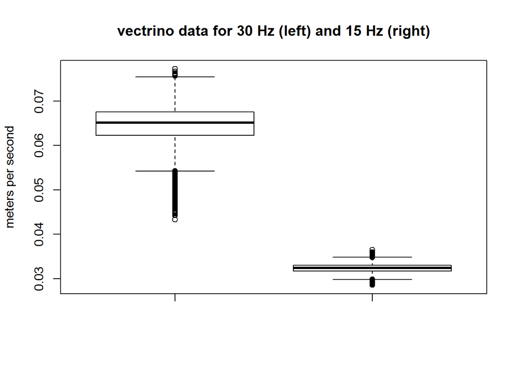

```r
vel920 <- vectrino920$Data[3:6]
vel1005 <- vectrino1005$Data[3:6]

for (i in 1:length(vel920)) vel920[[i]][[1]] <- rowMeans(vel920[[i]][[1]])

vel920 <- sqrt(vel920[[1]][[1]]^2 + vel920[[2]][[1]]^2 + vel920[[3]][[1]]^2)

for (i in 1:length(vel1005)) vel1005[[i]][[1]] <- rowMeans(vel1005[[i]][[1]])

vel1005 <- sqrt(vel1005[[1]][[1]]^2 + vel1005[[2]][[1]]^2 + vel1005[[3]][[1]]^2)

boxplot(vel920[20000:60000], vel1005[20000:60000], main = "vectrino data for 30 Hz (left) and 15 Hz (right)", ylab = "meters per second")
```

```r
mean(vel920[20000:60000])
```

```
## [1] 0.06460835
```

```r
mean(vel1005[20000:60000])
```

```
## [1] 0.03231724
```

These flow velocities are close enough to our expected ratio, 2:1, that I’m comfortable just using that.

# Sediment trap data

We employed nine small sediment traps on the bottom to get absolute values for particle settling. These can be used in tandem with the pump samples to differentiate between settling and collection. Traps were given alphabetical identifiers, beginning with the A, upstream-leftmost sediment trap, and progressing left to right, then upstream to downstream, ending with the I, the downstream-rightmost trap. All units are milligrams.

Trap diameter was 17/16“, or 2.698 cm. Hence, the area is in cm^2. Density is in mg/cm^2.

```r
trap920 <- read_csv("../../data/raw/920trapdata.csv")
trap1005 <- read_csv("../../data/raw/1005trapdata.csv")
```

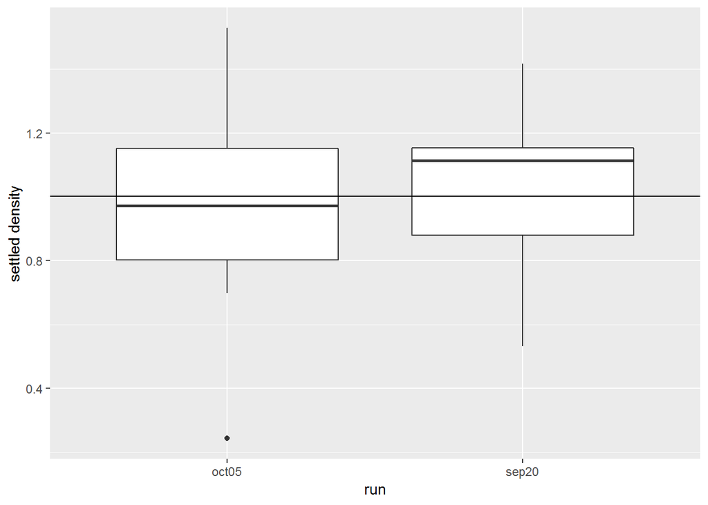

```r
trap1005 <- trap1005 %>%
  mutate('sediment mass' = post - pre, run = "oct05") %>%
  rename('trap letter' = X1)

trap920 <- trap920 %>%
  mutate(run = "sep20")

trap <- rbind(trap920, trap1005)

trap_area <- pi*(2.698^2/4)

trap <- trap %>%
  mutate(density = `sediment mass`/trap_area)

trap %>%
  ggplot(aes(run, density)) +
  geom_boxplot() +
  geom_hline(yintercept = mean(trap$density)) +
  ylab("settled density")
```

```r
rm(trap1005, trap920)
```

# Exponential model

The formula from Fauria for water concentration over time in a flume of constant velocity follows an exponential form:

$$\phi_a = \phi_{a,0} \cdot e^{kt}$$

$\phi_a$ is concentration at height $a$. $k$ is a coefficient, comprising settling ($k_s$) and particle capture on stems ($k_c$). $t$ is time. For the runs in this model so far, there have been zero collectors, meaining $k = k_s$. $k_s$ is calculated from another equation. We need to figure out vertical diffusion still to get an expected ratio to compare our model against, but $k \sim 1 - \frac{C}{u}$, where $u$ is flow velocity. Hence, lower velocity would be predicted to result in a lower k.

```r
model1005 <- lm(log(mvc) ~ time, data = filter(pump, run=="oct05"))
summary(model1005)
```

```
##
## Call:
## lm(formula = log(mvc) ~ time, data = filter(pump, run == "oct05"))
##
## Residuals:
##      Min       1Q   Median       3Q      Max
## -1.19412 -0.09171  0.02228  0.09400  0.61038
##
## Coefficients:
##               Estimate Std. Error t value Pr(>|t|)
## (Intercept)  3.124e+00  5.258e-02   59.42   <2e-16 ***
## time        -1.955e-04  1.437e-05  -13.61   <2e-16 ***
## ---
## Signif. codes:  0 '***' 0.001 '**' 0.01 '*' 0.05 '.' 0.1 ' ' 1
##
## Residual standard error: 0.249 on 111 degrees of freedom
##   (1 observation deleted due to missingness)
## Multiple R-squared:  0.6253, Adjusted R-squared:  0.6219
## F-statistic: 185.2 on 1 and 111 DF,  p-value: < 2.2e-16
```

```r
model920 <- lm(log(mvc) ~ time, data = filter(pump, run=="sep20"))
summary(model920)
```

```
##
## Call:
## lm(formula = log(mvc) ~ time, data = filter(pump, run == "sep20"))
##
## Residuals:
##      Min       1Q   Median       3Q      Max
## -2.22875 -0.12662  0.02873  0.16322  0.70126
##
## Coefficients:
##               Estimate Std. Error t value Pr(>|t|)
## (Intercept)  3.0592556  0.0632296   48.38   <2e-16 ***
## time        -0.0001970  0.0000171  -11.52   <2e-16 ***
## ---
## Signif. codes:  0 '***' 0.001 '**' 0.01 '*' 0.05 '.' 0.1 ' ' 1
##
## Residual standard error: 0.296 on 110 degrees of freedom
##   (2 observations deleted due to missingness)
## Multiple R-squared:  0.5468, Adjusted R-squared:  0.5427
## F-statistic: 132.7 on 1 and 110 DF,  p-value: < 2.2e-16
```

```r
model1019 <- lm(log(mvc) ~ time, data = filter(pump, run=="oct 19"))
summary(model1019)
```

```
##
## Call:
## lm(formula = log(mvc) ~ time, data = filter(pump, run == "oct 19"))
##
## Residuals:
##      Min       1Q   Median       3Q      Max
## -0.18096 -0.08705 -0.03253  0.07680  0.30614
##
## Coefficients:
##               Estimate Std. Error t value Pr(>|t|)
## (Intercept)  3.750e+00  1.528e-02  245.33   <2e-16 ***
## time        -1.078e-04  2.633e-06  -40.94   <2e-16 ***
## ---
## Signif. codes:  0 '***' 0.001 '**' 0.01 '*' 0.05 '.' 0.1 ' ' 1
##
## Residual standard error: 0.1148 on 142 degrees of freedom
## Multiple R-squared:  0.9219, Adjusted R-squared:  0.9213
## F-statistic:  1676 on 1 and 142 DF,  p-value: < 2.2e-16
```

```r
model1019s <-lm(log(mvc) ~ time, data = filter(pump, run=="oct 19", time<6001))
summary(model1019s)
```

```
##
## Call:
## lm(formula = log(mvc) ~ time, data = filter(pump, run == "oct 19",
##     time < 6001))
##
## Residuals:
##      Min       1Q   Median       3Q      Max
## -0.14451 -0.03879 -0.00674  0.04417  0.16388
##
## Coefficients:
##               Estimate Std. Error t value Pr(>|t|)
## (Intercept)  3.908e+00  1.079e-02  362.16   <2e-16 ***
## time        -1.620e-04  3.003e-06  -53.94   <2e-16 ***
## ---
## Signif. codes:  0 '***' 0.001 '**' 0.01 '*' 0.05 '.' 0.1 ' ' 1
##
## Residual standard error: 0.0569 on 118 degrees of freedom
## Multiple R-squared:  0.961,  Adjusted R-squared:  0.9607
## F-statistic:  2910 on 1 and 118 DF,  p-value: < 2.2e-16
```

```r
model1019l <-lm(log(mvc) ~ time, data = filter(pump, run=="oct 19", time>6001))
summary(model1019l)
```

```
##
## Call:
## lm(formula = log(mvc) ~ time, data = filter(pump, run == "oct 19",
##     time > 6001))
##
## Residuals:
##       Min        1Q    Median        3Q       Max
## -0.079739 -0.006895  0.001254  0.015483  0.063035
##
## Coefficients:
##               Estimate Std. Error t value Pr(>|t|)
## (Intercept)  3.339e+00  2.782e-02  120.02   <2e-16 ***
## time        -6.647e-05  2.372e-06  -28.02   <2e-16 ***
## ---
## Signif. codes:  0 '***' 0.001 '**' 0.01 '*' 0.05 '.' 0.1 ' ' 1
##
## Residual standard error: 0.03195 on 22 degrees of freedom
## Multiple R-squared:  0.9727, Adjusted R-squared:  0.9715
## F-statistic: 785.3 on 1 and 22 DF,  p-value: < 2.2e-16
```

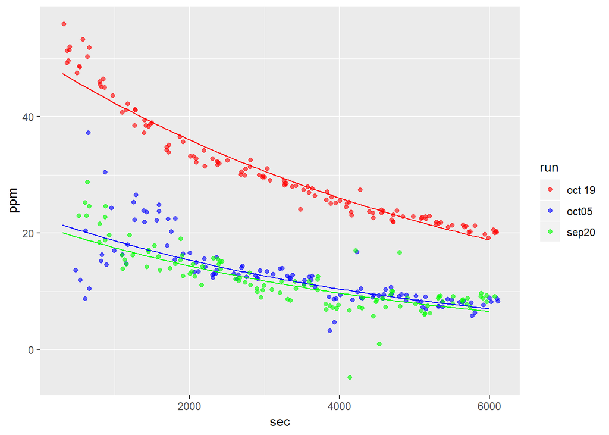

```r
pump %>%
  filter(time<6001) %>%
  ggplot(aes(time, mvc, color = run, group = time)) +
  geom_jitter(alpha = .6) +
  scale_color_manual(values = c("red","blue","green")) +
  stat_function(fun = function(x) exp(model920$coefficients[1]+model920$coefficients[2]*x), color = "green") +
  stat_function(fun = function(x) exp(model1005$coefficients[1]+model1005$coefficients[2]*x), color = "blue") +
  stat_function(fun = function(x) exp(model1019s$coefficients[1]+model1019s$coefficients[2]*x), color = "red") +
  xlab("sec") +
  ylab("ppm")
```

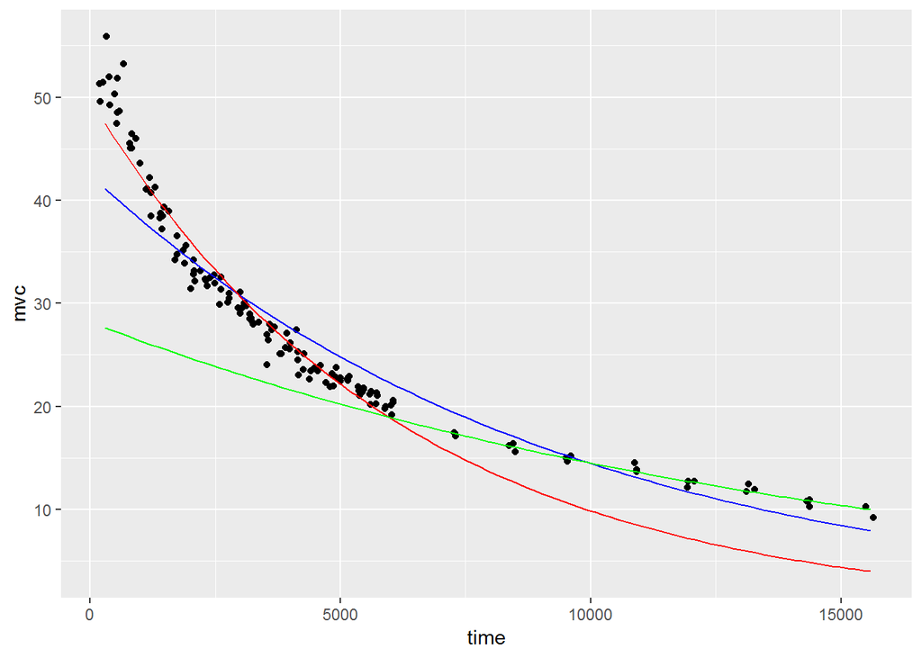

```r
pump %>%
  filter(run=="oct 19") %>%
  ggplot(aes(time, mvc)) +
  geom_jitter() +
  stat_function(fun = function(x) exp(model1019$coefficients[1]+model1019$coefficients[2]*x), color = "blue") +
  stat_function(fun = function(x) exp(model1019s$coefficients[1]+model1019s$coefficients[2]*x), color = "red") +
  stat_function(fun = function(x) exp(model1019l$coefficients[1]+model1019l$coefficients[2]*x), color = "green")
```

```r
subset_model <- function(start = 600, increment = 600, n = 8) {

  stattable <- tibble(start = 0,
                        end = 0,
                        sep20k = 0,
                        sep20r2 = 0,
                        oct05k = 0,
                        oct05r2 = 0,
                        oct19k = 0,
                        oct19r2 = 0)

  for (i in 1:n) {

    temp <- pump %>%
      filter(time>start, time<(start + increment*i))

    sep20 <- lm(log(mvc) ~ time, data = filter(temp, run == 'sep20'))
    oct05 <- lm(log(mvc) ~ time, data = filter(temp, run == 'oct05'))
    oct19 <- lm(log(mvc) ~ time, data = filter(temp, run == 'oct 19'))

    stattable[i, 1] <- start
    stattable[i, 2] <- start + increment*i
    stattable[i, 3] <- tidy(sep20)$estimate[2]
    stattable[i, 4] <- glance(sep20)$r.squared
    stattable[i, 5] <- tidy(oct05)$estimate[2]
    stattable[i, 6] <- glance(oct05)$r.squared
    stattable[i, 7] <- tidy(oct19)$estimate[2]
    stattable[i, 8] <- glance(oct19)$r.squared
  }

  return(stattable)
}

subset_model(200, 300, 20)
```

[output not shown]

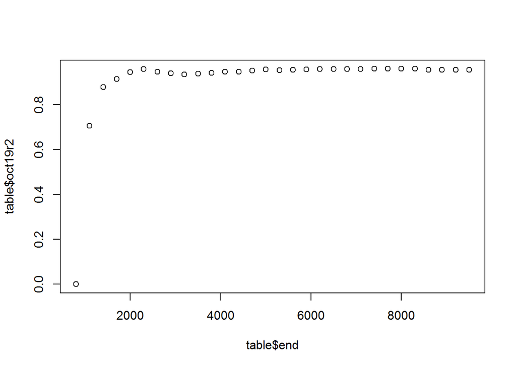

```r
subset_modeloct19 <-function(start = 600, increment = 600, n = 8) {

  stattable <- tibble(start = 0,
                        end = 0,
                        oct19k = 0,
                        oct19r2 = 0)

  for (i in 1:n) {

    temp <- pump %>%
      filter(time>start, time<(start + increment*i))

    oct19 <- lm(log(mvc) ~ time, data = filter(temp, run == 'oct 19'))

    stattable[i, 1] <- start
    stattable[i, 2] <- start + increment*i
    stattable[i, 3] <- tidy(oct19)$estimate[2]
    stattable[i, 4] <- glance(oct19)$r.squared
  }

  return(stattable)
}

table <- subset_modeloct19(500, 300, 30)

plot(y = table$oct19r2, x = table$end)
```

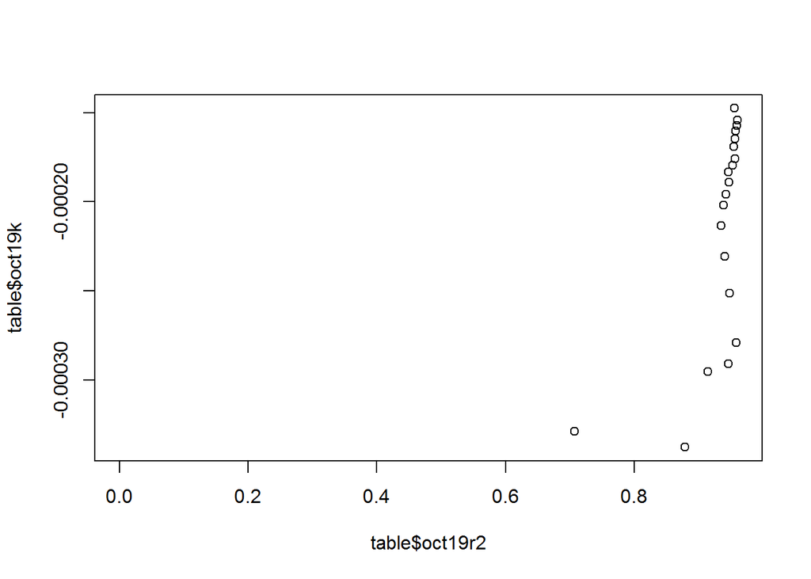

```r
plot(y = table$oct19k, x = table$oct19r2)
```

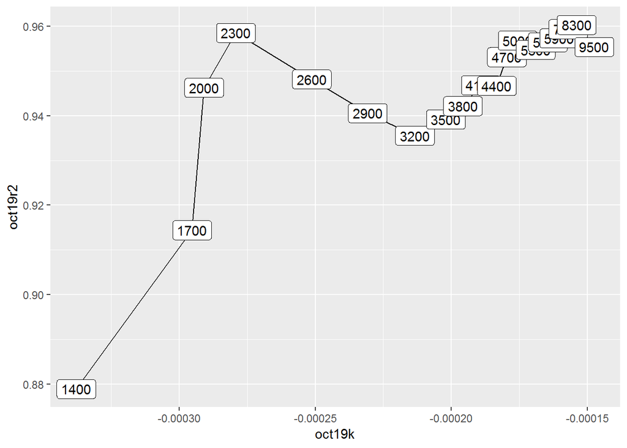

```r
table %>%
  filter(oct19r2 > .75) %>%
  ggplot(aes(oct19k, oct19r2, label = end)) +
  geom_path() +
  geom_point() +
  geom_label()
```